# GIF it, GIF it real good

Jesse M

2018-02-26

We’re going to walk through the basics of posting GIFs on your [blogdown](https://bookdown.org/yihui/blogdown/) website using [imgur](https://imgur.com/) and [GIPHY](https://giphy.com/).

## Introduction

Blogdown is an amazing tool for - *wait for it* - blogging. I recently made the jump to blogdown, and after working out all of my self-inflicted initial “OMG what happened *now*?!” issues, blogdown has become part of my daily workflow. I’m still playing with formatting issues (evidence below) but on the whole things are coming together nicely.

[figure not shown]

**me & blogdown** *(Why is this text so far away from the image? How do I put it closer, to serve as more of a caption? How do I move text to the top? If you know, Twitter me!)*

## You said there would be GIFs

If you know me, you know that I love to communicate using GIFs. So naturally one of the first things I looked into was how to use GIFs with blogdown, which resulted in finding [this post](https://blogdown-demo.rbind.io/2018/01/31/gif-animations/).

There’s nothing wrong with this method, but it’s a bit too technical for my needs, because really when I say GIF I’m referring to internet memes and not some amazingly useful and helpful [ggplot2](http://ggplot2.tidyverse.org/)-generated graph.

*Edit: after writing this post, the blogdown reference post linked above was updated to include the methods outlined in this post.*

### What you need

- an [imgur](https://imgur.com/) account (see the ‘Updates’ section below to bypass imgur)
- a GIF to share on your website - I use [GIPHY](https://giphy.com/) for 99% of my GIFfing needs
- blogdown up and running on your computer

### What to do

1. Find your GIF - I’m going to use the search terms “knope dance” on GIPHY
2. Within GIPHY, click on your GIF and then click on download (I usually choose Source)
3. Go to imgur. Hover over your account name, and then select ‘Images’ from the dropdown menu, like so:

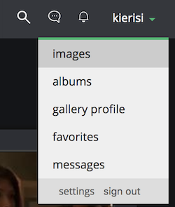

4. Upload your GIF to imgur by whatever means floats your boat (drag and drop or using the ‘Add images’ button)
5. Click on the thumbnail of your GIF to get the following screen:

[figure not shown]

6. Copy the link in the ‘Original GIF Link’ box - this is the URL that ends in **.gif**, *not .gifv*
7. In blogdown we link to an image using the following:  
   -> template: `![]()`  
   -> template with guide words: `![placeholder text](your URL goes here)`
8. In the ‘placeholder text’ space, type in whatever text you’d like to appear under your GIF, and paste your GIF URL in between the parentheses
9. Profit!

[figure not shown]

the above GIF was created using: `![](https://i.imgur.com/fAevDKc.gif)`

## Updates!

*Many thanks to [Alison Hill](https://twitter.com/apreshill) for sharing the following resources:*

- [You can link *directly* to GIPHY (or other sites)](https://alison.rbind.io/post/r-ladies-slides/), which removes the need for imgur uploads
- And for information on figure captions, [look no further](https://blogdown-demo.rbind.io/2017/10/06/adding-figures-and-other-images-to-posts/)!